# Analisis Kontribusi Pendapatan Berdasarkan Rating Film

Arofah Arroyani_M0725002

2026-05-24

```r
#Pemuatan paket library
library(knitr)
library(DBI)
library(odbc)
library(ggplot2)
```

## Pendahuluan

Laporan ini menyajikan analisis pendapatan berdasarkan rating film dari database **Sakila**. Proses analisis mengintegrasikan **MySQL** untuk pengambilan data dan **R** untuk visualisasi serta uji statistik. Variabel yang digunakan dalam analisis ini adalah rating sebagai variabel independen yang berasal dari tabel film, serta amount sebagai variabel dependen yang berasal dari tabel payment.

## Deskripsi Insight

Dalam industri perfilman, setiap film yang diedarkan telah melalui proses sensor dan mendapatkan rating penonton seperti G, PG, PG-13, R, hingga NC-17. Adapun, arti dari masing-masing rating sebagai berikut:

- **G (General Audiences)** : Semua usia, tanpa batasan.
- **PG (Parental Guidance Suggested)** : Perlu bimbingan orang tua untuk anak di bawah usia tertentu.
- **PG-13 (Parents Strongly Cautioned)** : Tidak disarankan untuk anak di bawah 13 tahun.
- **R (Restricted)** : Usia minimal 17 tahun.
- **NC-17 (No One 17 and Under Admitted)** : Usia minimal 18 tahun, tidak boleh untuk anak di bawah 17 tahun.

Regulasi rating film berdampak pada operasional bisnis rental DVD, terutama dalam hal pengelolaan stok dan strategi pemasaran. Database Sakila menyediakan data yang relevan untuk mengeksplorasi isu tersebut. Berdasarkan regulasi rating, film diklasifikasikan menjadi dua kelompok:

1. **Kelompok Keluarga** : rating G dan PG (dapat diakses semua kalangan).
2. **Kelompok Dewasa** : rating R dan NC-17 (khusus pelanggan dewasa).

Rating PG-13 tidak termasuk bagian antara dua kelompok tersebut. Analisis ini bertujuan untuk menganalisis **kontribusi pendapatan berdasarkan rating film**, serta menguji apakah **terdapat perbedaan yang signifikan antara pendapatan kelompok rating keluarga (G, PG) dan kelompok rating dewasa (R, NC-17)**. Hasil analisis diharapkan dapat memberikan gambaran yang jelas tentang masing-masing kelompok rating berkontribusi terhadap total pendapatan, serta menjadi pertimbangan dalam pengelolaan stok dan kebijakan penyewaan DVD.

### Koneksi Database Sakila

```r
con_Sakila <- DBI::dbConnect(odbc::odbc(),
                             Driver = "MySQL ODBC 8.0 ANSI Driver",
                             Server = "127.0.0.1",
                             Database = "sakila",
                             UID = "root",
                             PWD = "kata sandi kamu",
                             Port = 3306)
```

### **Stok Awal Film**

Berikut adalah gambaran stok film (DVD) berdasarkan rating di database Sakila. Data ini berfungsi sebagai informasi awal untuk melihat kesesuaian alokasi stok dengan kontribusi pendapatan.

```r
stok_film<-dbGetQuery(con_sakila, "SELECT rating, COUNT(`inventory_id`) AS STOK_FILM
from film
JOIN inventory USING (film_id)
WHERE rating in ('G', 'PG', 'R', 'NC-17')
GROUP BY rating")

kable(stok_film,
      col.names = c("Rating Film", "Jumlah Stok"),
      format = "html",
      table.attr = 'class="my-table"')
```

| Rating Film | Jumlah Stok |
| --- | --- |
| PG | 924 |
| G | 791 |
| NC-17 | 944 |
| R | 904 |

## Visualisasi Data

### Visualisasi Perbandingan Total Pendapatan Berdasarkan Rating Film

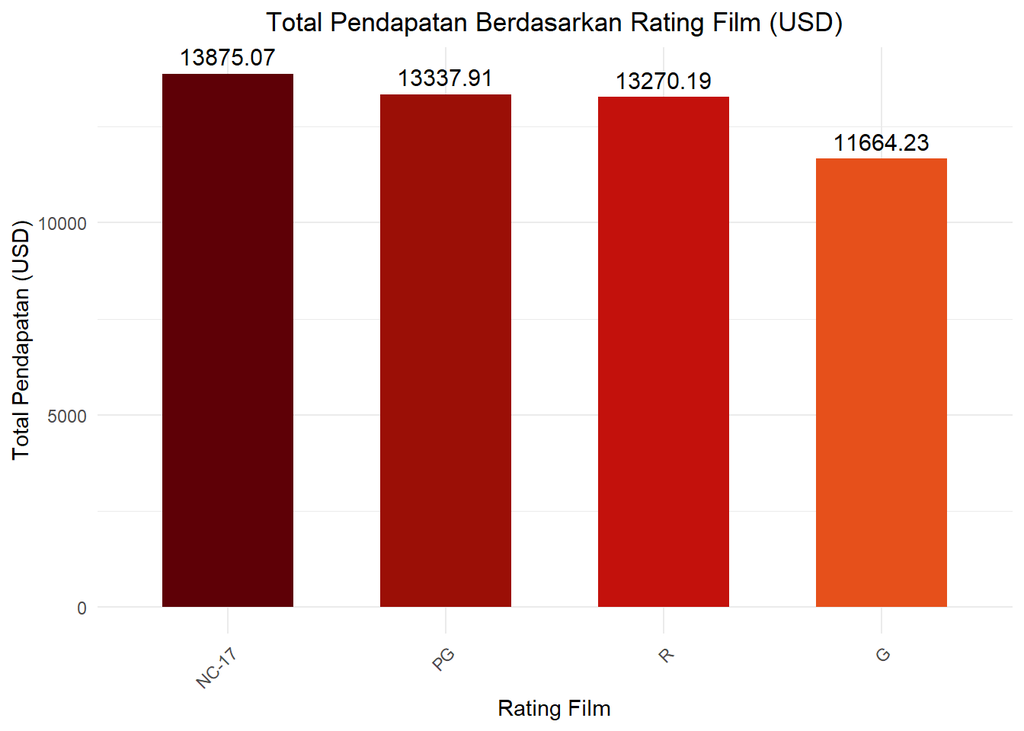

```r
dt_profit <- dbGetQuery(con_sakila, "SELECT rating, SUM(amount) AS TOTAL_PENDAPATAN
FROM film
JOIN inventory using (film_id)
JOIN rental using (inventory_id)
JOIN payment using (rental_id)
WHERE rating IN ('G', 'PG', 'R', 'NC-17')
GROUP BY rating
ORDER BY TOTAL_PENDAPATAN DESC")

bar_profit<- ggplot(dt_profit, aes(x = reorder(rating, -TOTAL_PENDAPATAN), y = TOTAL_PENDAPATAN)) +
  geom_bar(stat = "identity", fill = c("#5E0006", "#9B0F06", "#C3110C", "#E6501B"), alpha = 1, width=0.6) +
  geom_text(aes(label = round(TOTAL_PENDAPATAN, 2)), vjust = -0.5, size = 4) +
  theme_minimal() +
  labs(
    title = "Total Pendapatan Berdasarkan Rating Film (USD)",
    x = "Rating Film",
    y = "Total Pendapatan (USD)"
  ) +
  theme(axis.text.x = element_text(angle = 45, hjust = 1),
        plot.title = element_text(hjust = 0.5))
bar_profit
```

### **Interpretasi Hasil**

Diagram batang di atas menyajikan perbandingan total pendapatan berdasarkan rating film, yakni G, PG, R, dan NC-17 dalam satuan USD (Dolar Amerika Serikat). Total pendapatan per rating film berfungsi sebagai indikator untuk mengetahui kontribusi masing-masing rating terhadap keseluruhan pendapatan. Berdasarkan diagram tersebut, rating **NC-17 (No One 17 and Under Admitted)** merupakan penyumbang pendapatan tertinggi sebesar **13.875.07**, diikuti oleh **PG (Parental Guidance Suggested)** sebesar **13.337.91**, **R (Restricted)** sebesar **13.270.19**, dan **G (General Audiences)** sebagai penyumbang terendah sebesar **11.664.23**. Meskipun NC-17 menempati posisi tertinggi, secara visual perbedaan antar rating tidak terlalu signifikan, sehingga kontribusi keempat rating relatif seimbang. Dengan demikian, strategi yang tepat untuk dilakukan adalah mempertahankan keseimbangan stok antar rating serta melakukan analisis lanjutan terhadap faktor lain seperti musim, lokasi toko, dan karakteristik pelanggan untuk mengoptimalkan pendapatan secara menyeluruh.

## Analisis Data

### Analisis Perbandingan Pendapatan antara Kelompok Rating Keluarga dan Dewasa

Untuk menguji perbedaan pendapatan antara kelompok rating Keluarga (G dan PG) dengan kelompok Dewasa (R dan NC-17), digunakan uji **Mann-Whitney (Wilcoxon rank-sum test)** dengan tingkat signifikansi $\alpha$ = 0.05. Uji ini dipilih karena tidak mensyaratkan asumsi normalitas dan homogenitas varians, sehingga cocok untuk data pendapatan yang umumnya tidak terdistribusi normal.

**Persamaan Matematis Uji Mann-Whitney :**

$$U = n_1 n_2 + \frac{n_1(n_1+1)}{2} - R_1$$

Keterangan:

- $n_1$ = jumlah sampel kelompok pertama (Keluarga)
- $n_2$ = jumlah sampel kelompok kedua (Dewasa)
- $R_1$ = jumlah peringkat (rank sum) dari kelompok pertama

Karena ukuran sampel yang besar, digunakan pendekatan normal dengan persamaan:

$$z = \frac{U - \mu_U}{\sigma_U}$$

di mana:

$$\begin{align}
\mu_U &= \frac{n_1 n_2}{2} \\
\sigma_U &= \sqrt{\frac{n_1 n_2 (n_1 + n_2 + 1)}{12}}
\end{align}$$

Hipotesis :

$$\begin{align}
H_0 &: \mu_{\text{Keluarga}} = \mu_{\text{Dewasa}} \\
H_1 &: \mu_{\text{Keluarga}} \neq \mu_{\text{Dewasa}}
\end{align}$$

```r
dt_keluarga<- dbGetQuery(con_sakila, "SELECT 'Keluarga' AS kelompok, rating AS rating_film, amount AS pendapatan
FROM payment
JOIN rental using (rental_id)
JOIN inventory using (inventory_id)
JOIN film using (film_id)
WHERE rating IN ('G','PG')")
dt_dewasa<- dbGetQuery(con_sakila, "SELECT 'Dewasa' AS kelompok, rating AS rating_film, amount AS pendapatan
FROM payment
JOIN rental using (rental_id)
JOIN inventory using (inventory_id)
JOIN film using (film_id)
WHERE rating IN ('R','NC-17')")

dt_uji_mann <- rbind(dt_keluarga, dt_dewasa)

keluarga <- dt_keluarga$pendapatan[dt_keluarga$kelompok == "Keluarga"]
dewasa <- dt_dewasa$pendapatan[dt_dewasa$kelompok == "Dewasa"]

hasil_uji_mann <- wilcox.test(keluarga, dewasa, paired = FALSE, correct = TRUE)

hasil_uji_mann
```

```
##
##  Wilcoxon rank sum test with continuity correction
##
## data:  keluarga and dewasa
## W = 19222380, p-value = 0.4441
## alternative hypothesis: true location shift is not equal to 0
```

### **Interpretasi Hasil**

Berdasarkan uji Mann-Whitney (Wilcoxon rank sum test) yang telah dilakukan untuk membandingkan pendapatan antara kelompok rating Keluarga (G dan PG) dengan kelompok rating Dewasa (R dan NC-17), diperoleh $p\text{-value} = 0,4441$. Karena $p\text{-value}$ > $0.05$ (tingkat signifikansi), maka **$H_0$ gagal ditolak**. Dengan demikian, **tidak terdapat perbedaan yang signifikan secara statistik antara pendapatan kelompok rating Keluarga (G dan PG) dengan kelompok rating Dewasa (R dan NC-17)**. Secara matematis, hal ini dapat dinyatakan sebagai:

$$\mu_{\text{Keluarga}} = \mu_{\text{Dewasa}}$$

Artinya, meskipun terdapat perbedaan nominal pada total pendapatan antar rating, secara statistik perbedaan tersebut tidak cukup kuat untuk menyatakan bahwa satu kelompok rating lebih unggul dari kelompok lainnya. Faktor rating film tidak berpengaruh signifikan terhadap pendapatan yang dihasilkan.

### Kesimpulan dan Saran

Berdasarkan analisis pendapatan berdasarkan rating film di database Sakila, rating NC-17 memiliki total pendapatan tertinggi (13.875.07 USD), diikuti PG (13.337.91 USD), R (13.270.19 USD), dan G (11.664.23 USD). Namun, hasil uji Mann-Whitney menunjukkan nilai $p\text{-value} = 0,4441 > 0,05$, sehingga tidak terdapat perbedaan signifikan antara pendapatan kelompok rating Keluarga (G dan PG) dan Dewasa (R dan NC-17). Artinya, semua rating film memberikan kontribusi pendapatan yang relatif seimbang. Oleh karena itu, manajemen disarankan untuk mempertahankan keseimbangan stok antar rating, tetap mempertahankan stok NC-17 karena memiliki permintaan tertinggi, serta melakukan analisis lanjutan terhadap faktor musim, lokasi toko, dan karakteristik pelanggan untuk mengoptimalkan pendapatan secara lebih spesifik.